# Image Compressor

Jaxon Lara

2026-09-25

# Image Compression Function

```r
comp <- function(X, k){

  V <- crossprod(X)
  eig <- eigen(V)
  U <- eig$vectors

  Z <- X %*% U

  X_k <- Z[, 1:k, drop=FALSE] %*% t(U[, 1:k, drop=FALSE])
  error_k <- norm(X-X_k, type="F")

  return(list(approximation=X_k, error=error_k))
}

uz <- function(X){
  V <- crossprod(X)
  eig <- eigen(V)
  U <- eig$vectors
  Z <- X %*% U
  return(list(u=U, z=Z))
}
```

# Examples

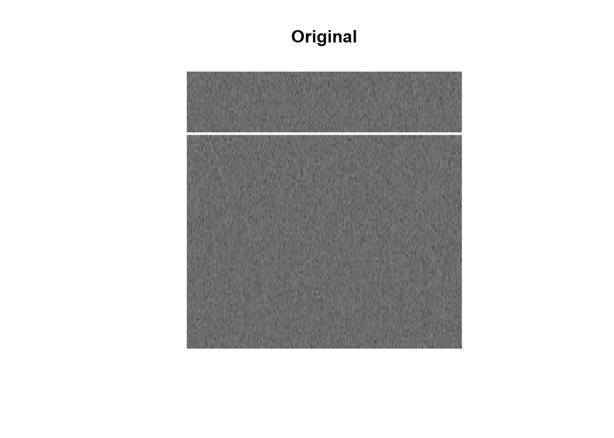

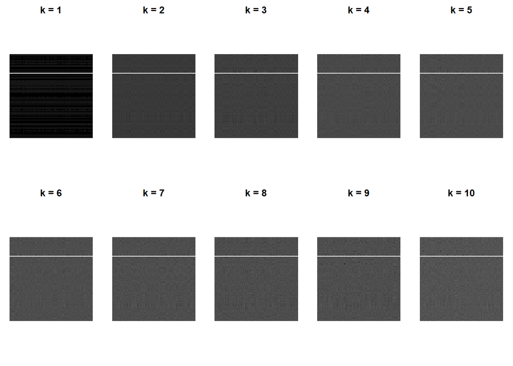

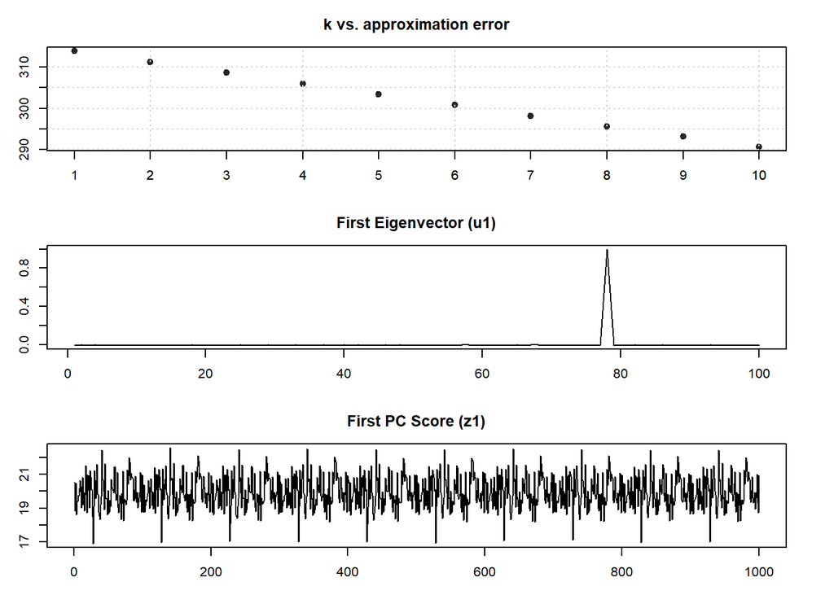

The approximation error appears to steadily decrease linearily which suggest the image’s information is spread fairly evenly across many components.

The first eigenvector plot shows nearly a single spike at one column index which shows that PDC is dominated by a single strip in the image.

The pc score appears to track that line’s pixels which being similar enough throughout essentially shows up as noise.

For this image I would say that k=8 gives a sufficiently good approximation of the original image.

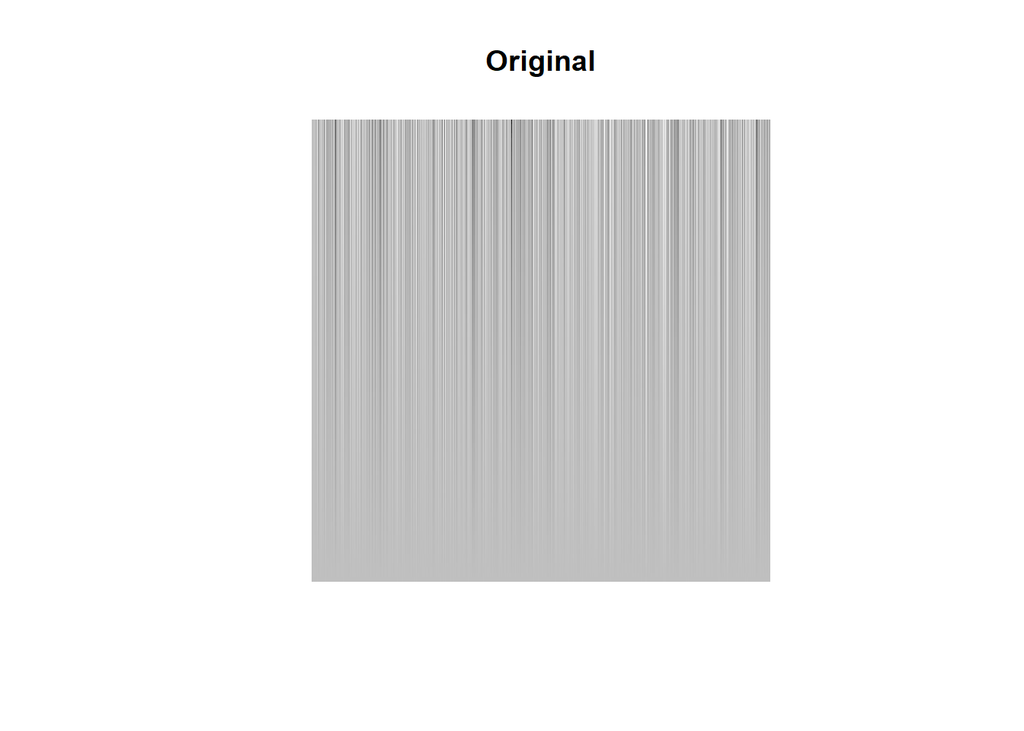

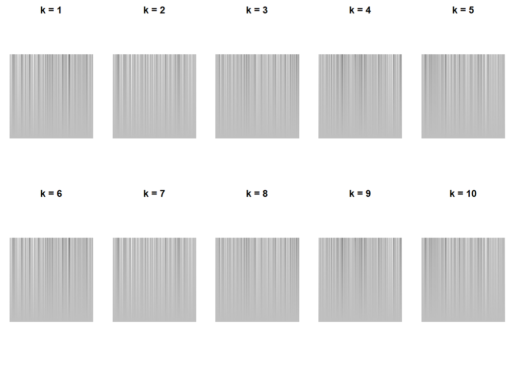

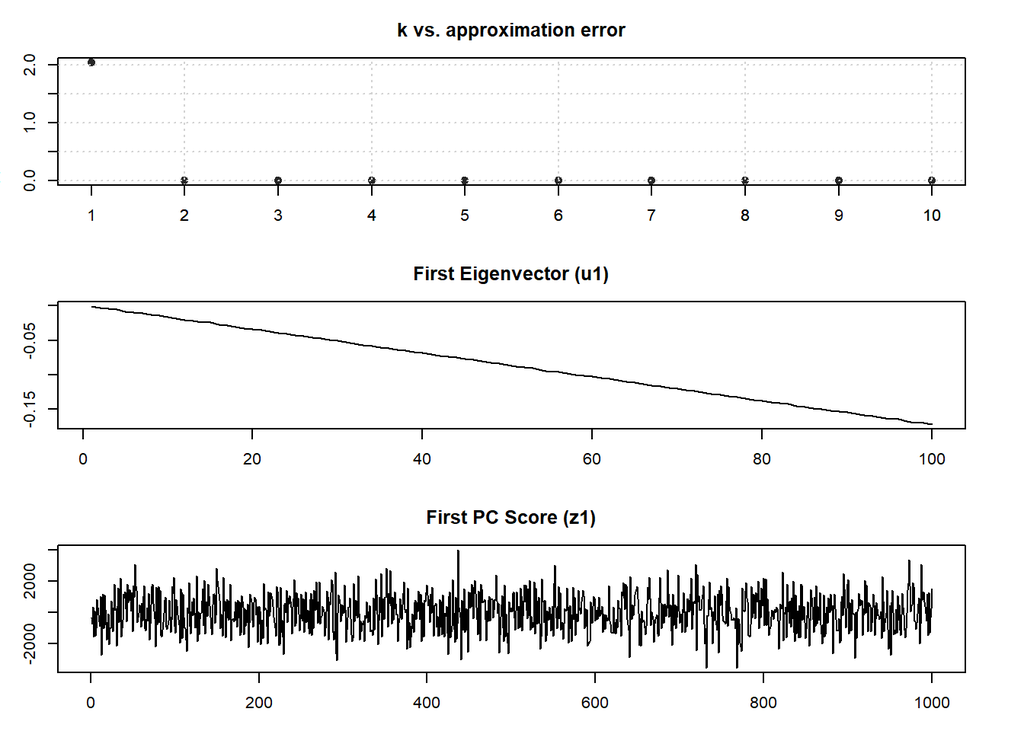

The approximation error in this one dips sharply after 1 which suggests nearly all the image’s information can be gleamed from the first component.

The first pc score is also noisy, indicating that the striping pattern captured is applied with roughly similar strength throughout the image.

For this image I would say that k=1 gives a sufficiently good approximation of the original image.

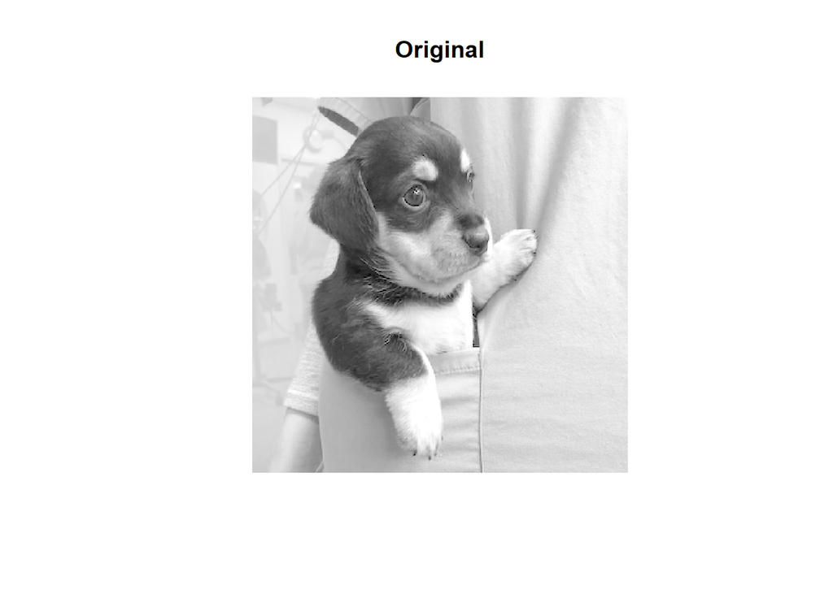

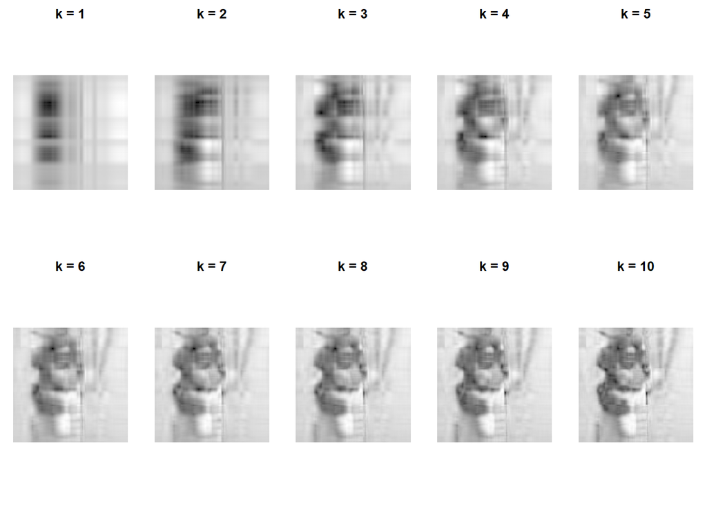

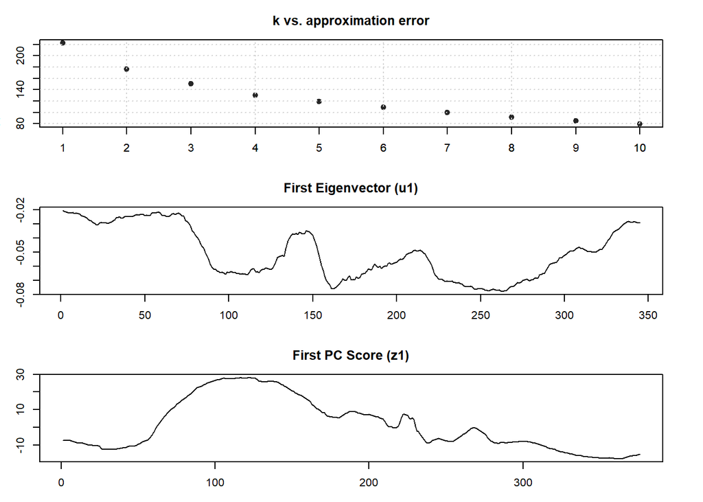

The approximation error plot shows a steep drop from 1 to 3 but decrease slower for k=4 through 10. This shows that though the first 3 components provide a lot of information there is still much to be added incrementally by other components.

The smooth but bumpy graph of the first eigenvector indicates the image has a distinct patch of columns in the center of the image.

The first pc score is similarly smooth and bumpy which indicates that the image doesn’t have one consistent pattern throughout. But instead has patches of light and dark pixels.

For this image I would say that k=7 gives a sufficiently good approximation of the original image. Though even then a lot of fine detail is lost.

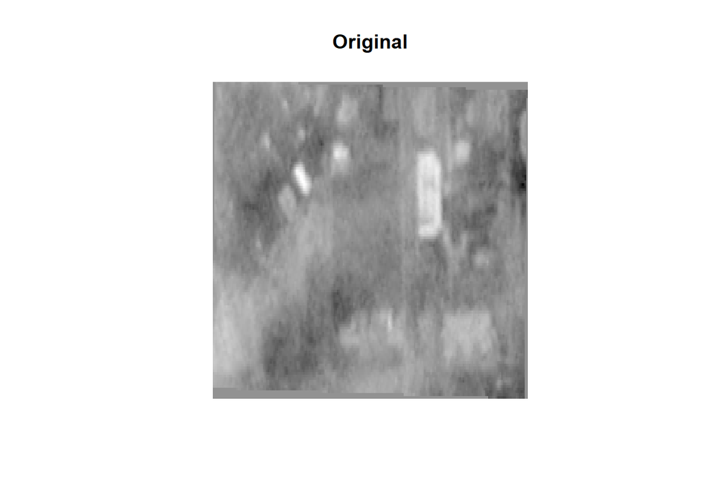

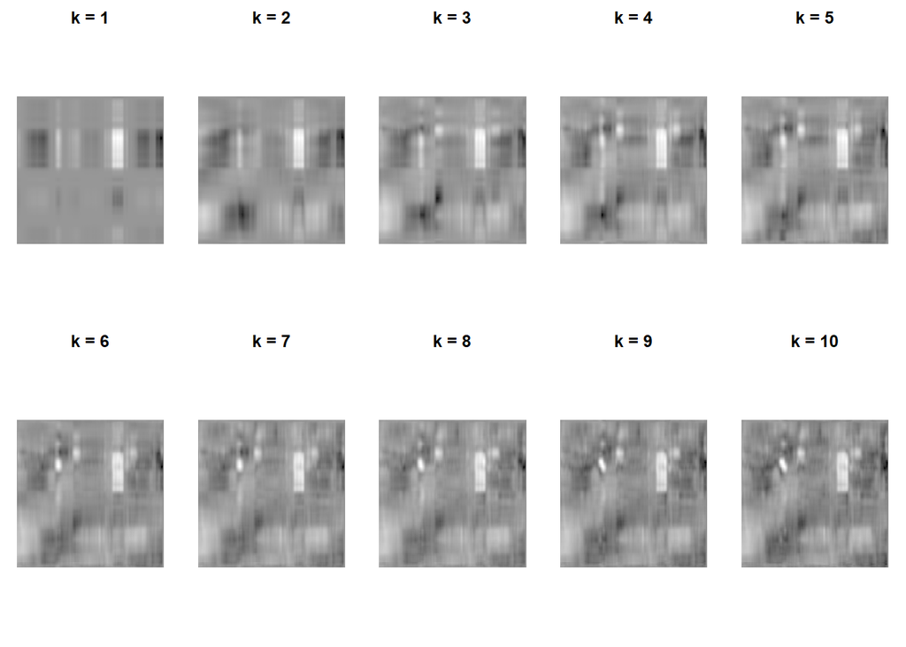

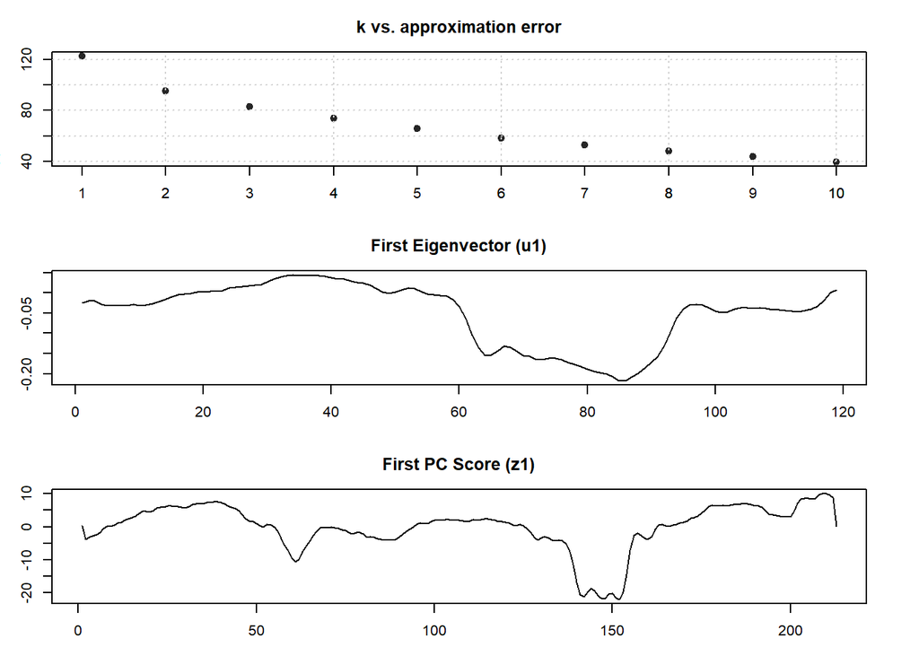

The approximation error plot shows a steady decline that flattens out towards k=10. This shows that similar to the 3rd image the first component of this image gives the rough general shape of the image but requires many more components to fill in the gaps.

The first eigenvector plot has a smooth valley like trend which suggests there is a distinct patch of pixels off to the right of the image which can be confirmed visually where there is a distinctly white rectangle which doesn’t blend in with the rest of the image.

Similarly the first pc score graph is smooth with some distinct dips where the image has distinct patches of pixels.

For this image I would say that k=6 gives a sufficiently good approximation of the original image.